# analyzing personal movement using activity monitoring devices

mirzarashid abbasov | reproducible research course - project 1 | coursera

18.OCT.2017

## Synopsis

There are many ways and possible to collect a large amount of data about personal movement using activity monitoring devices. These type of devices are part of the “quantified self” movement – a group of enthusiasts who take measurements about themselves regularly to improve their health, to find patterns in their behavior. This assignment makes use of data from a personal activity monitoring device. The data for this assignment can be downloaded from: [Dataset: Activity monitoring data](https://d396qusza40orc.cloudfront.net/repdata%2Fdata%2Factivity.zip)

The dataset variables included:

```
* steps: Number of steps taking in a 5-minute interval (missing values are coded as NA)

* date: The date on which the measurement was taken in YYYY-MM-DD format

* interval: Identifier for the 5-minute interval in which measurement was taken
```

## Library loading

```r
suppressMessages(library(R.utils))
suppressMessages(library(dplyr))
suppressMessages(library(ggplot2))
suppressMessages(library(gridExtra))
```

## Loading and preprocessing the data

1. Code for reading in the dataset and/or processing the data

```r
knitr::opts_chunk$set(echo = TRUE)

# set working directory
setwd("/Users/mirzarashid.abbasov/repos/Reproducible_research/week2")

# clean up workspance
rm(list = ls())

# set source url link
url <- "https://d396qusza40orc.cloudfront.net/repdata%2Fdata%2Factivity.zip"

# downloand data from url
download.file(url, "activity.zip")

# convert to the csv format
if(!file.exists('activity.csv')){
  unzip('activity.zip')
}

# read data from source files to the temp variable
temp <- read.csv("activity.csv", header=T, sep=',')

head(temp)
```

```
##   steps       date interval
## 1    NA 2012-10-01        0
## 2    NA 2012-10-01        5
## 3    NA 2012-10-01       10
## 4    NA 2012-10-01       15
## 5    NA 2012-10-01       20
## 6    NA 2012-10-01       25
```

## Data processing & results

### What is mean total number of steps taken per day?

#### 2. Histogram of the total number of steps taken each day

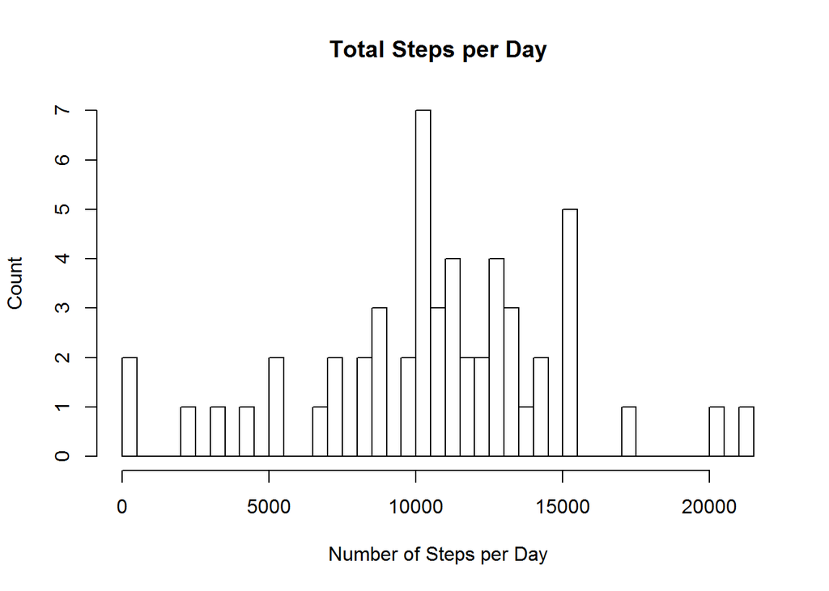

```r
knitr::opts_chunk$set(echo = TRUE)

##select steps & date from data.frame
result.steps <- temp %>% select(steps, date) %>%
        ## exclude all NA values from steps column
        filter(!is.na(steps)) %>%
        group_by(date) %>%
        ##calculate sum & mean & median grouped by date
        summarise(total.steps = sum(steps))

##histogram of count per day
hist(result.steps$total.steps,
        main="Total Steps per Day",
        xlab="Number of Steps per Day",
        ylab = "Count",
        breaks=50)
```

### What is mean total number of steps taken per day?

#### 3. Mean and median number of steps taken each day

```r
## calculate mean of steps taken each day
mean <- mean(result.steps$total.steps)
mean
```

```
## [1] 10766.19
```

```r
## calculate median of steps taken each day
median <- median(result.steps$total.steps)
median
```

```
## [1] 10765
```

### What is the average daily activity pattern?

#### 4. Time series plot of the average number of steps taken

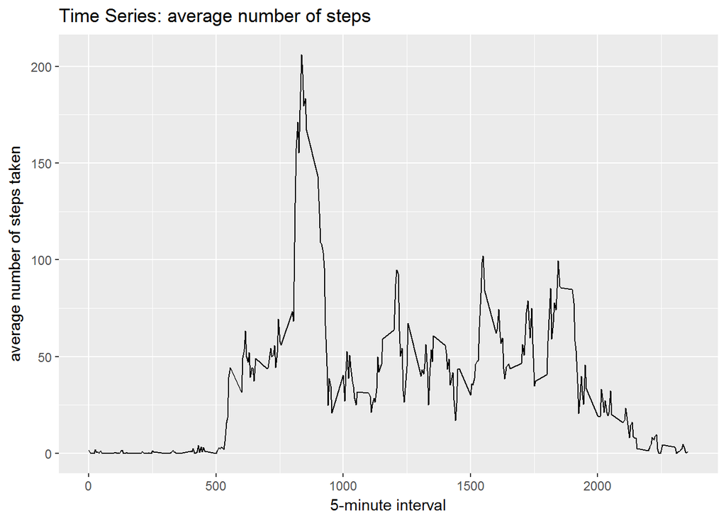

```r
##select steps & date from data.frame
result.mean <- temp %>% select(steps, interval) %>%
        ## exclude all NA values from steps column
        filter(!is.na(steps)) %>%
        group_by(interval) %>%
        ##calculate sum & mean & median grouped by date
        summarise(total.steps = mean(steps))

##create a plot
ggplot(data=result.mean,
       aes(x = interval, y = total.steps)) +
        geom_line() +
        ggtitle("Time Series: average number of steps") +
        xlab("5-minute interval") +
        ylab("average number of steps taken")
```

#### 5. The 5-minute interval that, on average, contains the maximum number of steps

```r
result.max <- temp %>% select(steps, interval) %>%
        ## exclude all NA values from steps column
        filter(!is.na(steps)) %>%
        group_by(interval) %>%
        ##calculate sum & mean & median grouped by date
        summarise(total.steps = sum(steps)) %>%
        arrange(desc(total.steps)) %>% ##descending results
        head(result.max, n=1L) ##only TOP 20

## maximum interval number
result.max$interval
```

```
## [1] 835
```

```r
## maximum steps per interval
result.max$total.steps
```

```
## [1] 10927
```

### Imputing missing values

#### 6. Code to describe and show a strategy for imputing missing data

Use approximation method to fill missing data for example to use median() or mean()

```r
## number of NA recods before
before <- sum(is.na(temp$steps))
before
```

```
## [1] 2304
```

```r
## to fill missing values with mean
temp$steps[is.na(temp$steps)] <- mean(temp$steps[!is.na(temp$steps)])

## number of NA recods after
after <- sum(is.na(temp$steps))
after
```

```
## [1] 0
```

### Are there differences in activity patterns between weekdays and weekends

#### 7. Histogram of the total number of steps taken each day after missing values are imputed

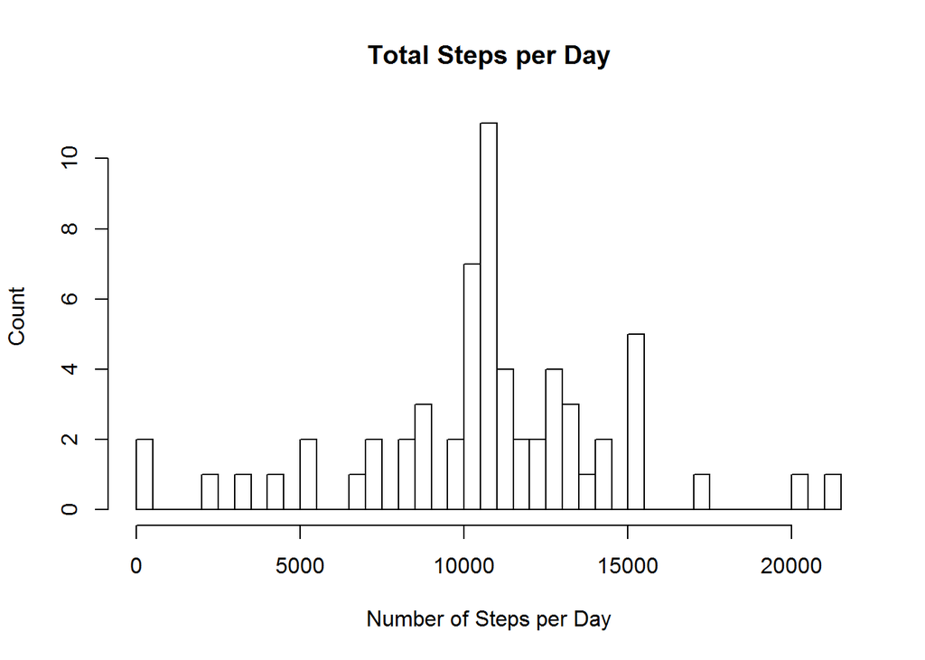

```r
##select steps & date from data.frame
result.steps <- temp %>% select(steps, date) %>%
        ## exclude all NA values from steps column
        filter(!is.na(steps)) %>%
        group_by(date) %>%
        ##calculate sum & mean & median grouped by date
        summarise(total.steps = sum(steps))

##histogram of count per day
hist(result.steps$total.steps,
        main="Total Steps per Day",
        xlab="Number of Steps per Day",
        ylab = "Count",
        breaks=50)
```

#### 8. Panel plot comparing the average number of steps taken per 5-minute interval across weekdays and weekends

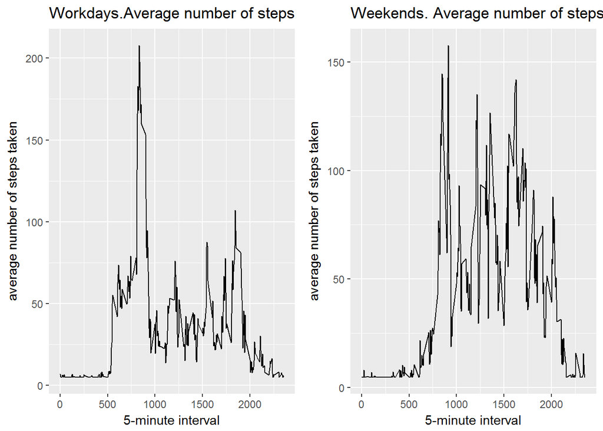

```r
##weekdays as a decimal number(1-7, Monday is 1)

##create a data.frame with weekends days
temp.weekends <- temp[strftime(temp$date, format = "%u") > 5, ]

##create a data.frame with workdays
temp.workdays <- temp[strftime(temp$date, format = "%u") < 6, ]

##select steps & date from data.frame
result.weekends <- temp.weekends %>% select(steps, interval) %>%
        ## exclude all NA values from steps column
        filter(!is.na(steps)) %>%
        group_by(interval) %>%
        ##calculate sum & mean & median grouped by date
        summarise(total.steps = mean(steps))

##select steps & date from data.frame
result.workdays <- temp.workdays %>% select(steps, interval) %>%
        ## exclude all NA values from steps column
        filter(!is.na(steps)) %>%
        group_by(interval) %>%
        ##calculate sum & mean & median grouped by date
        summarise(total.steps = mean(steps))


##create a plot for weekends
g.weekends <-   ggplot(data=result.weekends,
                aes(x = interval, y = total.steps)) +
                geom_line() +
                ggtitle("Weekends. Average number of steps") +
                xlab("5-minute interval") +
                ylab("average number of steps taken")

##create a plot for workdays
g.workdays <-   ggplot(data=result.workdays,
                aes(x = interval, y = total.steps)) +
                geom_line() +
                ggtitle("Workdays.Average number of steps") +
                xlab("5-minute interval") +
                ylab("average number of steps taken")

##create a final plot
grid.arrange(g.workdays, g.weekends, ncol=2)
```

##### Conclusion

As you can see from the figure above, activity on weekends is higher than on working days.

###### Mirzarashid Abbasov, almaty, 2017